# The predictive modeling pipeline

### Introduce the notebook and live coding

- I will walk through the notebook and explain as I type
- You have to slow me down when I am too fast (also the helper!); ask questions anytime
- We'll have exercises
- The collaborative document keeps track of the code in case you fall behind

## Objectives

- build intuitions about an unknown dataset
- identify and differentiate numerical and categorical features
- create an advanced predictive pipeline with scikit-learn

## (1) Tabular data exploration

### First look at our dataset

Necessary steps before any machine learning happens:

- load the data
- look at the variables in the dataset: numerical vs categorical variables --> they need different processing
- visualize the distribution of the variables to gain insights into the dataset

#### Loading the adult census dataset

- see openml website: https://www.openml.org/search?type=data&sort=runs&id=1590&status=active

```python
import pandas as pd
```

```python
adult_census = pd.read_csv("../datasets/adult-census.csv")
```

**Goal**: we would like to predict whether a person earns more than 50k a year from data such as

- age
- employment
- education
- family information

#### The variables in the dataset

- `pandas` dataframe = data composed of 2 dimensions. "tabular data"
  - one row = one "sample" // "record", "instance", "observation"
  - one column = attribute of the observation // "variable", "attribute", "covariate"

```python
adult_census.head()
```

|  | age | workclass | education | education-num | marital-status | occupation | relationship | race | sex | capital-gain | capital-loss | hours-per-week | native-country | class |
| --- | --- | --- | --- | --- | --- | --- | --- | --- | --- | --- | --- | --- | --- | --- |
| 0 | 25 | Private | 11th | 7 | Never-married | Machine-op-inspct | Own-child | Black | Male | 0 | 0 | 40 | United-States | <=50K |
| 1 | 38 | Private | HS-grad | 9 | Married-civ-spouse | Farming-fishing | Husband | White | Male | 0 | 0 | 50 | United-States | <=50K |
| 2 | 28 | Local-gov | Assoc-acdm | 12 | Married-civ-spouse | Protective-serv | Husband | White | Male | 0 | 0 | 40 | United-States | >50K |
| 3 | 44 | Private | Some-college | 10 | Married-civ-spouse | Machine-op-inspct | Husband | Black | Male | 7688 | 0 | 40 | United-States | >50K |
| 4 | 18 | ? | Some-college | 10 | Never-married | ? | Own-child | White | Female | 0 | 0 | 30 | United-States | <=50K |

- column `class` is the *target variable* -- variable we want to predict
- binary prediction: `class` has two possible values
- we will use the remaining columns as input variables for the models

Let's see the distribution over the two classes with the `value_counts()` method.

```python
target_column = "class"
adult_census[target_column].value_counts()
```

```
class
 <=50K    37155
 >50K     11687
Name: count, dtype: int64
```

Class imbalance *in the outcome variable*

- needs special techniques for predictive modeling (intuition: model ignores small groups because they are less important in the objective function)
- example: medical setting with rare diseases -> many people will be healthy

Column types

- numerical -- continuous values
- categorical -- finite number of values

NOTE copy-paste the code below $\rightarrow$ inform helper

ALTERNATIVE: go through each column (except the target) and fill out which type a column is?

```python
numerical_columns = [
    "age",
    "education-num",
    "capital-gain",
    "capital-loss",
    "hours-per-week",
]
categorical_columns = [
    "workclass",
    "education",
    "marital-status",
    "occupation",
    "relationship",
    "race",
    "sex",
    "native-country",
]
```

```python
all_columns = numerical_columns + categorical_columns + [target_column]
```

```python
# let's just make sure we only have the cells we are interested in
adult_census = adult_census[all_columns]
```

```python
adult_census.shape
```

```
(48842, 14)
```

```python
# Check the number of observations and number of columns
# print(
#     f"The dataset contains {adult_census.shape[0]} samples and "
#     f"{adult_census.shape[1]} columns"
# )
```

[output not shown]

NOTE Explain what `df.shape` does

```python
?adult_census.shape
```

```
Type:        property
String form: <property object at 0x7fbaac13b650>
Docstring:
Return a tuple representing the dimensionality of the DataFrame.

See Also
--------
ndarray.shape : Tuple of array dimensions.

Examples
--------
>>> df = pd.DataFrame({'col1': [1, 2], 'col2': [3, 4]})
>>> df.shape
(2, 2)

>>> df = pd.DataFrame({'col1': [1, 2], 'col2': [3, 4],
...                    'col3': [5, 6]})
>>> df.shape
(2, 3)
```

```python
# since 1 column is the dataset, we can count the number of features as
# print(f"The dataset contains {adult_census.shape[1] - 1} features.")
```

[output not shown]

#### Visually inspecting the data

Good idea to look at the data before building a predictive model

- maybe the task we are trying to solve does not need ML (example: average wages of men in the United States -- but that is not a predictive model)
- check the information necessary for the task is in the data
- find data peculiarities: missing data, capped values, ...

NOTE First run without the `_ =` to show its impact. "garbage variable" we don't need

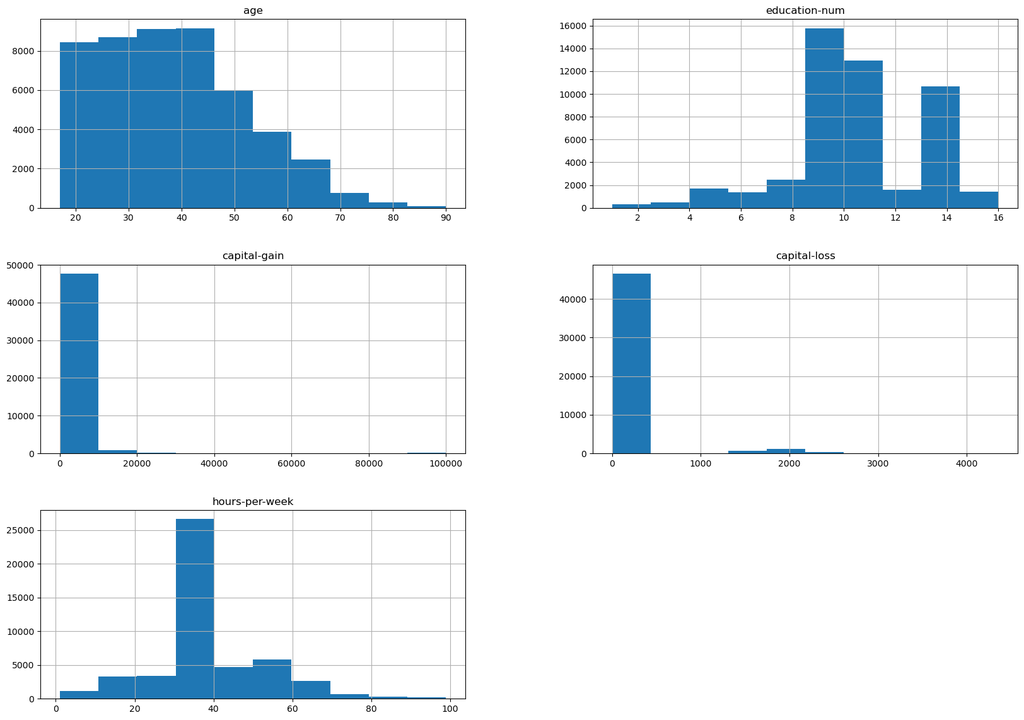

```python
_ = adult_census.hist(figsize=(20, 14)) # size in inches
```

What have we done?

- `hist` creates a histogram. It is built-in to the dataframe object and makes one histogram per numerical variable. Convenient for quickly exploring data
- the x axis shows the values of the variable and the y axis shows the number of samples in each bin of x

Call-out What do we see in these histograms?

- "age": few data beyond 70. reason: data filtered `hours-per-week` > 0 (data description)
- "education-num": peak around 10-13, but unclear where exactly
- "hours-per-week": peak at 40 -- standard number of hours worked at the time when data were collected
- "capital-gain", "capital-loss": most values close to 0.

For categorical variables, look at the distribution as follows

```python
adult_census["sex"].value_counts()
```

```
sex
 Male      32650
 Female    16192
Name: count, dtype: int64
```

(Explain the output: `name`, `dtype`.)

**Class imbalance in the features**

- many more men than women (-- perhaps b/c hours-per-week > 0?)
- this can lead to disproportionate prediction errors for under-represented groups -- fairness problems in ML when systems deployed naively
- fairlearn.org: learn more about makeing ML fair across social groups. https://fairlearn.org/

```python
adult_census["education"].value_counts()
```

```
education
 HS-grad         15784
 Some-college    10878
 Bachelors        8025
 Masters          2657
 Assoc-voc        2061
 11th             1812
 Assoc-acdm       1601
 10th             1389
 7th-8th           955
 Prof-school       834
 9th               756
 12th              657
 Doctorate         594
 5th-6th           509
 1st-4th           247
 Preschool          83
Name: count, dtype: int64
```

What is the relation between `education` and `education-num`?

```python
pd.crosstab(
    index=adult_census["education"], columns=adult_census["education-num"]
)
```

| education-num education | 1 | 2 | 3 | 4 | 5 | 6 | 7 | 8 | 9 | 10 | 11 | 12 | 13 | 14 | 15 | 16 |
| --- | --- | --- | --- | --- | --- | --- | --- | --- | --- | --- | --- | --- | --- | --- | --- | --- |
| 10th | 0 | 0 | 0 | 0 | 0 | 1389 | 0 | 0 | 0 | 0 | 0 | 0 | 0 | 0 | 0 | 0 |
| 11th | 0 | 0 | 0 | 0 | 0 | 0 | 1812 | 0 | 0 | 0 | 0 | 0 | 0 | 0 | 0 | 0 |
| 12th | 0 | 0 | 0 | 0 | 0 | 0 | 0 | 657 | 0 | 0 | 0 | 0 | 0 | 0 | 0 | 0 |
| 1st-4th | 0 | 247 | 0 | 0 | 0 | 0 | 0 | 0 | 0 | 0 | 0 | 0 | 0 | 0 | 0 | 0 |
| 5th-6th | 0 | 0 | 509 | 0 | 0 | 0 | 0 | 0 | 0 | 0 | 0 | 0 | 0 | 0 | 0 | 0 |
| 7th-8th | 0 | 0 | 0 | 955 | 0 | 0 | 0 | 0 | 0 | 0 | 0 | 0 | 0 | 0 | 0 | 0 |
| 9th | 0 | 0 | 0 | 0 | 756 | 0 | 0 | 0 | 0 | 0 | 0 | 0 | 0 | 0 | 0 | 0 |
| Assoc-acdm | 0 | 0 | 0 | 0 | 0 | 0 | 0 | 0 | 0 | 0 | 0 | 1601 | 0 | 0 | 0 | 0 |
| Assoc-voc | 0 | 0 | 0 | 0 | 0 | 0 | 0 | 0 | 0 | 0 | 2061 | 0 | 0 | 0 | 0 | 0 |
| Bachelors | 0 | 0 | 0 | 0 | 0 | 0 | 0 | 0 | 0 | 0 | 0 | 0 | 8025 | 0 | 0 | 0 |
| Doctorate | 0 | 0 | 0 | 0 | 0 | 0 | 0 | 0 | 0 | 0 | 0 | 0 | 0 | 0 | 0 | 594 |
| HS-grad | 0 | 0 | 0 | 0 | 0 | 0 | 0 | 0 | 15784 | 0 | 0 | 0 | 0 | 0 | 0 | 0 |
| Masters | 0 | 0 | 0 | 0 | 0 | 0 | 0 | 0 | 0 | 0 | 0 | 0 | 0 | 2657 | 0 | 0 |
| Preschool | 83 | 0 | 0 | 0 | 0 | 0 | 0 | 0 | 0 | 0 | 0 | 0 | 0 | 0 | 0 | 0 |
| Prof-school | 0 | 0 | 0 | 0 | 0 | 0 | 0 | 0 | 0 | 0 | 0 | 0 | 0 | 0 | 834 | 0 |
| Some-college | 0 | 0 | 0 | 0 | 0 | 0 | 0 | 0 | 0 | 10878 | 0 | 0 | 0 | 0 | 0 | 0 |

What do we see?

- entries in `education` and `education-num` correspond exactly to each other
  - they give us the same information
- --> we can remove `education-num` without losing information

Let's do this for future reference

NOTE: do not drop `"education-num`" already; it's used below for the pairplot

We can also inspect the data with a pairplot, and show how each variable differs according to the target variable.

NOTE copy-paste the code below

Note to helper

> Copy the code for creating the plots into the collaborative document. Since our course is on ML and not on plotting, we don't want to spend time on explaining this code.

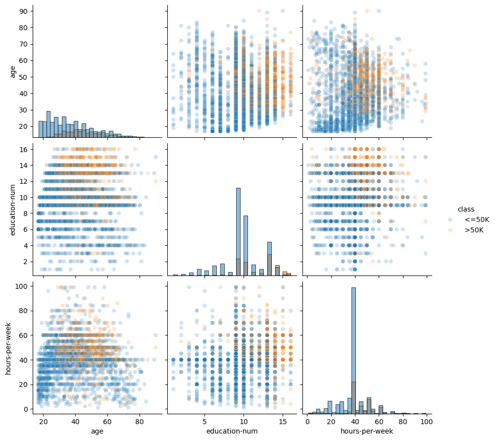

```python
import seaborn as sns

# We will plot a subset of the data to keep the plot readable and make the
# plotting faster
n_samples_to_plot = 5000
columns = ["age", "education-num", "hours-per-week"]
_ = sns.pairplot(
    data=adult_census[:n_samples_to_plot],
    vars=columns,
    hue=target_column,
    plot_kws={"alpha": 0.2},
    height=3,
    diag_kind="hist",
    diag_kws={"bins": 30},
)
```

Call-out: what do we see?

#### Creating decision rules by hand

From the previous plot (bottom left): create some rule by hand with the `hours-per-week` and `age` features

NOTE copy-paste the code below

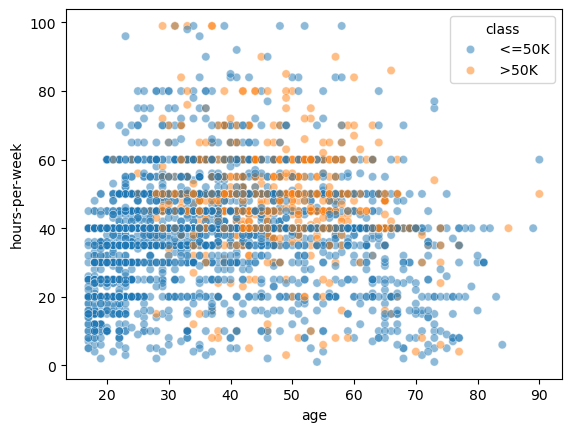

```python
_ = sns.scatterplot(
    x="age",
    y="hours-per-week",
    data=adult_census[:n_samples_to_plot],
    hue=target_column,
    alpha=0.5,
)
```

Explain this on the board if possible

- young people, below 27, almost all have low income
- above 27, there seem to be 2 groups
  - those with low hours per week, say below 40, have low income
  - those with hours 40 or more, the prediction is much less clear
- we will see later that some methods -- decision tree -- work similar to what we did here, but they select the thresholds automatically (and in an optimal way)
- moreover, ML is handy precisely in cases where it's not obvious to the human eye
  - like in the last group above
  - or when there are many features

**In sum**

- ML automatically creates the rules from the existing data to make predictions on new unseen data.

#### Wrap-up: important observations

- if target is imbalanced, special techniques are necessary for training and evaluating the model
- redundant (highly correlated) features can be a problem for some ML algorithms

### Exercise M1.01: exploring a dataset

**Questions: see the exercise document, header "Data exploration"**

#### Solutions

```python
penguins = pd.read_csv("../datasets/penguins_classification.csv")
```

```python
penguins.head()
```

|  | Culmen Length (mm) | Culmen Depth (mm) | Species |
| --- | --- | --- | --- |
| 0 | 39.1 | 18.7 | Adelie |
| 1 | 39.5 | 17.4 | Adelie |
| 2 | 40.3 | 18.0 | Adelie |
| 3 | 36.7 | 19.3 | Adelie |
| 4 | 39.3 | 20.6 | Adelie |

```python
nrows, ncols = penguins.shape
print(f"The data have {nrows} rows and {ncols} cols")
```

```
The data have 342 rows and 3 cols
```

**(1) How many features are numerical? How many features are categorical?**

features

- culmen length and depth are numerical
- (species is the outcome and is categorical -- to the extent this is considered a feature)

**(2) What are the different penguins species available in the dataset and how many samples of each species are there?**

```python
target_column = "Species"
penguins[target_column].value_counts()
```

```
Species
Adelie       151
Gentoo       123
Chinstrap     68
Name: count, dtype: int64
```

**(3) Plot histograms for the numerical features**

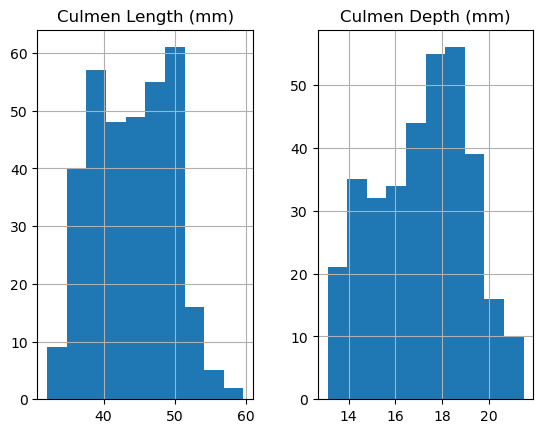

```python
_ = penguins.hist()
```

**(4) Plot features distribution for each class (Hint: use `seaborn.pairplot`).**

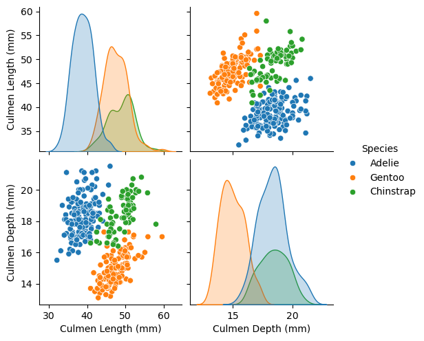

```python
# We will plot a subset of the data to keep the plot readable and make the
# plotting faster
_ = sns.pairplot(penguins, hue="Species")
```

**(5) Looking at the distributions you got, how hard do you think it will be to classify the penguins only using "culmen depth" and "culmen length"?**

It looks like classification should not be too hard -- the groups seem well separated from each other based on the numerical features

## (2) Handling categorical data, encoding

### Encoding of categorical variables

Question to audience : what are examples of categorical data?

- gender
- place of work
- ...

```python
# adult_census = pd.read_csv("../datasets/adult-census.csv")
```

```python
# drop duplicated column
# adult_census = adult_census.drop(columns="education-num")
adult_census = adult_census.drop(columns="education-num")
```

```python
target_name = "class"
target = adult_census[target_name]
data = adult_census.drop(columns=[target_name])
```

#### Identify categorical variables

they are different from the numerical variables

- they are often encoded as strings
- they have a finite set of different values

Explain what the command below does

- `value_counts`: counts occurences of each group
- `sort_index()`: sorts by index, here the index is native-country (this index is created by the precending function)

```python
data["native-country"].value_counts().sort_index()
```

```
native-country
 ?                               857
 Cambodia                         28
 Canada                          182
 China                           122
 Columbia                         85
 Cuba                            138
 Dominican-Republic              103
 Ecuador                          45
 El-Salvador                     155
 England                         127
 France                           38
 Germany                         206
 Greece                           49
 Guatemala                        88
 Haiti                            75
 Holand-Netherlands                1
 Honduras                         20
 Hong                             30
 Hungary                          19
 India                           151
 Iran                             59
 Ireland                          37
 Italy                           105
 Jamaica                         106
 Japan                            92
 Laos                             23
 Mexico                          951
 Nicaragua                        49
 Outlying-US(Guam-USVI-etc)       23
 Peru                             46
 Philippines                     295
 Poland                           87
 Portugal                         67
 Puerto-Rico                     184
 Scotland                         21
 South                           115
 Taiwan                           65
 Thailand                         30
 Trinadad&Tobago                  27
 United-States                 43832
 Vietnam                          86
 Yugoslavia                       23
Name: count, dtype: int64
```

we can easily recognize categorical columns with the data type

```python
data.dtypes
```

```
age                int64
capital-gain       int64
capital-loss       int64
hours-per-week     int64
workclass         object
education         object
marital-status    object
occupation        object
relationship      object
race              object
sex               object
native-country    object
dtype: object
```

the variable `"native-country"` is data type `object` -- this means it contains string values

Instead of manually selecting the columns, we can use the scikit-learn helper function `make_column_selector`. It allows us to select columns based on the data type

```python
from sklearn.compose import make_column_selector as selector
categorical_columns_selector = selector(dtype_include=object) #create the selector and pass argument about which data to include
categorical_columns # returns a list of column names that satisfy the specification in the selector
```

```
['workclass',
 'education',
 'marital-status',
 'occupation',
 'relationship',
 'race',
 'sex',
 'native-country']
```

Now we can select the columns in the original data set

```python
data_categorical = data[categorical_columns]
data_categorical.head()
```

|  | workclass | education | marital-status | occupation | relationship | race | sex | native-country |
| --- | --- | --- | --- | --- | --- | --- | --- | --- |
| 0 | Private | 11th | Never-married | Machine-op-inspct | Own-child | Black | Male | United-States |
| 1 | Private | HS-grad | Married-civ-spouse | Farming-fishing | Husband | White | Male | United-States |
| 2 | Local-gov | Assoc-acdm | Married-civ-spouse | Protective-serv | Husband | White | Male | United-States |
| 3 | Private | Some-college | Married-civ-spouse | Machine-op-inspct | Husband | Black | Male | United-States |
| 4 | ? | Some-college | Never-married | ? | Own-child | White | Female | United-States |

```python
print(f"The dataset is composed of {data_categorical.shape[1]} features")
```

```
The dataset is composed of 8 features
```

Now that we have the columns ready, we can look at different strategies to encode categorical data into numerical data, which are suited for machine learning

#### Strategies to encode categories

**Encoding ordinal categories**

Most intuitive: just assign a different number to each category. We can do this with the `OrdinalEncoder`.

```python
from sklearn.preprocessing import OrdinalEncoder

education_column = data_categorical[["education"]]

encoder = OrdinalEncoder().set_output(transform="pandas") # we set the output to pandas dataframe
education_encoded = encoder.fit_transform(education_column)

education_encoded
```

|  | education |
| --- | --- |
| 0 | 1.0 |
| 1 | 11.0 |
| 2 | 7.0 |
| 3 | 15.0 |
| 4 | 15.0 |
| ... | ... |
| 48837 | 7.0 |
| 48838 | 11.0 |
| 48839 | 11.0 |
| 48840 | 11.0 |
| 48841 | 11.0 |

48842 rows × 1 columns

```python
# ?OrdinalEncoder.set_output
```

We can see which values of the original columns receive which number -- starting at 0 and counting through. For example, the first row was "11th", and now is 1.0. Thus, "11th" is mapped to 1.0.

```python
encoder.categories_
```

```
[array([' 10th', ' 11th', ' 12th', ' 1st-4th', ' 5th-6th', ' 7th-8th',
        ' 9th', ' Assoc-acdm', ' Assoc-voc', ' Bachelors', ' Doctorate',
        ' HS-grad', ' Masters', ' Preschool', ' Prof-school',
        ' Some-college'], dtype=object)]
```

```python
# apply the encoding to all categorical features
data_encoded = encoder.fit_transform(data_categorical)
data_encoded[:5] # show the first five rows
```

|  | workclass | education | marital-status | occupation | relationship | race | sex | native-country |
| --- | --- | --- | --- | --- | --- | --- | --- | --- |
| 0 | 4.0 | 1.0 | 4.0 | 7.0 | 3.0 | 2.0 | 1.0 | 39.0 |
| 1 | 4.0 | 11.0 | 2.0 | 5.0 | 0.0 | 4.0 | 1.0 | 39.0 |
| 2 | 2.0 | 7.0 | 2.0 | 11.0 | 0.0 | 4.0 | 1.0 | 39.0 |
| 3 | 4.0 | 15.0 | 2.0 | 7.0 | 0.0 | 2.0 | 1.0 | 39.0 |
| 4 | 0.0 | 15.0 | 4.0 | 0.0 | 3.0 | 4.0 | 0.0 | 39.0 |

```python
print(f"The dataset encoded contains {data_encoded.shape[1]} features")
```

```
The dataset encoded contains 8 features
```

Observations

- each feature was encoded independently
- the number of features remains the same

**leave the below out -- see exercise instead** One needs to be careful when applying this encoding strategy

- the numbering implies that the values are ordered, for instance 0 < 1 < 2 < ...
- however, depending on the model we use, this can be misleading.
- first, the order may not be what we want. for instance, suppose we have a `"size"` variable with categories "S", "M", "L", "XL". The encoder would assign the values `2, 1, 0, 3` to these groups, following alphabetical order.
- for this case, one can specify the ordering explicitly. see here: https://scikit-learn.org/stable/modules/preprocessing.html#encoding-categorical-features
- second, sometimes having a number odes not even make sense, like in variable `"native-country"`.

(difficult to explain, leave out) moreover, it implies that changing from one neighboring category to the next is always the same "amount of change". this may make sense in some cases, but for instance for the country of origin

#### Exercise: ordinal encoding

header "ordinal encoding" in exercise document

*Answers:*

- A1: Only education (in fact, the encoder was already present in the data set as education-num), as this is the only one that can be expressed as an incremental feature
- A2: Examples could be:
  - Alphabetized: US grading system: A, B, C, D, F
  - Not alphabetized: clothing sizes: XS, S, M, L, XL, XXL
- A3: Would not be in correct order (it's alphabetized).
- AA4: top of documention will tell you to use `categories` argument with a list in the correct order

```
ordered_size_list = ['XS', 'S', 'M', 'L', 'XL', 'XXL']
encoder_with_order = OrdinalEncoder(categories=ordered_size_list)
```

- A5: US grading scheme is alphabetical to begin with (A,B,C,D,F)

**Encoding nominal categories -- without assuming any order**

This is an alternative encoder. It prevents the model from making false assumptions about the ordering of the categories.

-> `OneHotEncoder`

Encoding this way will create one new column for each category of a variable, containing `0`s and `1`s.

```python
from sklearn.preprocessing import OneHotEncoder

encoder = OneHotEncoder(sparse_output=False).set_output(transform="pandas")
# NOTE: we use sparse_output=False for illustration. In practice, it's better to use sparse_output=True, which is more memory efficient
education_encoded = encoder.fit_transform(education_column)
education_encoded
```

|  | education_ 10th | education_ 11th | education_ 12th | education_ 1st-4th | education_ 5th-6th | education_ 7th-8th | education_ 9th | education_ Assoc-acdm | education_ Assoc-voc | education_ Bachelors | education_ Doctorate | education_ HS-grad | education_ Masters | education_ Preschool | education_ Prof-school | education_ Some-college |
| --- | --- | --- | --- | --- | --- | --- | --- | --- | --- | --- | --- | --- | --- | --- | --- | --- |
| 0 | 0.0 | 1.0 | 0.0 | 0.0 | 0.0 | 0.0 | 0.0 | 0.0 | 0.0 | 0.0 | 0.0 | 0.0 | 0.0 | 0.0 | 0.0 | 0.0 |
| 1 | 0.0 | 0.0 | 0.0 | 0.0 | 0.0 | 0.0 | 0.0 | 0.0 | 0.0 | 0.0 | 0.0 | 1.0 | 0.0 | 0.0 | 0.0 | 0.0 |
| 2 | 0.0 | 0.0 | 0.0 | 0.0 | 0.0 | 0.0 | 0.0 | 1.0 | 0.0 | 0.0 | 0.0 | 0.0 | 0.0 | 0.0 | 0.0 | 0.0 |
| 3 | 0.0 | 0.0 | 0.0 | 0.0 | 0.0 | 0.0 | 0.0 | 0.0 | 0.0 | 0.0 | 0.0 | 0.0 | 0.0 | 0.0 | 0.0 | 1.0 |
| 4 | 0.0 | 0.0 | 0.0 | 0.0 | 0.0 | 0.0 | 0.0 | 0.0 | 0.0 | 0.0 | 0.0 | 0.0 | 0.0 | 0.0 | 0.0 | 1.0 |
| ... | ... | ... | ... | ... | ... | ... | ... | ... | ... | ... | ... | ... | ... | ... | ... | ... |
| 48837 | 0.0 | 0.0 | 0.0 | 0.0 | 0.0 | 0.0 | 0.0 | 1.0 | 0.0 | 0.0 | 0.0 | 0.0 | 0.0 | 0.0 | 0.0 | 0.0 |
| 48838 | 0.0 | 0.0 | 0.0 | 0.0 | 0.0 | 0.0 | 0.0 | 0.0 | 0.0 | 0.0 | 0.0 | 1.0 | 0.0 | 0.0 | 0.0 | 0.0 |
| 48839 | 0.0 | 0.0 | 0.0 | 0.0 | 0.0 | 0.0 | 0.0 | 0.0 | 0.0 | 0.0 | 0.0 | 1.0 | 0.0 | 0.0 | 0.0 | 0.0 |
| 48840 | 0.0 | 0.0 | 0.0 | 0.0 | 0.0 | 0.0 | 0.0 | 0.0 | 0.0 | 0.0 | 0.0 | 1.0 | 0.0 | 0.0 | 0.0 | 0.0 |
| 48841 | 0.0 | 0.0 | 0.0 | 0.0 | 0.0 | 0.0 | 0.0 | 0.0 | 0.0 | 0.0 | 0.0 | 1.0 | 0.0 | 0.0 | 0.0 | 0.0 |

48842 rows × 16 columns

Comment

- each category has become a column. It includes 1 when the observation falls into that category

We can apply this encoding to the full dataset.

```python
print(f"The dataset is composed of {data_categorical.shape[1]} features")
data_categorical.head()
```

```
The dataset is composed of 8 features
```

|  | workclass | education | marital-status | occupation | relationship | race | sex | native-country |
| --- | --- | --- | --- | --- | --- | --- | --- | --- |
| 0 | Private | 11th | Never-married | Machine-op-inspct | Own-child | Black | Male | United-States |
| 1 | Private | HS-grad | Married-civ-spouse | Farming-fishing | Husband | White | Male | United-States |
| 2 | Local-gov | Assoc-acdm | Married-civ-spouse | Protective-serv | Husband | White | Male | United-States |
| 3 | Private | Some-college | Married-civ-spouse | Machine-op-inspct | Husband | Black | Male | United-States |
| 4 | ? | Some-college | Never-married | ? | Own-child | White | Female | United-States |

```python
data_encoded = encoder.fit_transform(data_categorical)
```

```python
data_encoded[:5]
```

|  | workclass_ ? | workclass_ Federal-gov | workclass_ Local-gov | workclass_ Never-worked | workclass_ Private | workclass_ Self-emp-inc | workclass_ Self-emp-not-inc | workclass_ State-gov | workclass_ Without-pay | education_ 10th | ... | native-country_ Portugal | native-country_ Puerto-Rico | native-country_ Scotland | native-country_ South | native-country_ Taiwan | native-country_ Thailand | native-country_ Trinadad&Tobago | native-country_ United-States | native-country_ Vietnam | native-country_ Yugoslavia |
| --- | --- | --- | --- | --- | --- | --- | --- | --- | --- | --- | --- | --- | --- | --- | --- | --- | --- | --- | --- | --- | --- |
| 0 | 0.0 | 0.0 | 0.0 | 0.0 | 1.0 | 0.0 | 0.0 | 0.0 | 0.0 | 0.0 | ... | 0.0 | 0.0 | 0.0 | 0.0 | 0.0 | 0.0 | 0.0 | 1.0 | 0.0 | 0.0 |
| 1 | 0.0 | 0.0 | 0.0 | 0.0 | 1.0 | 0.0 | 0.0 | 0.0 | 0.0 | 0.0 | ... | 0.0 | 0.0 | 0.0 | 0.0 | 0.0 | 0.0 | 0.0 | 1.0 | 0.0 | 0.0 |
| 2 | 0.0 | 0.0 | 1.0 | 0.0 | 0.0 | 0.0 | 0.0 | 0.0 | 0.0 | 0.0 | ... | 0.0 | 0.0 | 0.0 | 0.0 | 0.0 | 0.0 | 0.0 | 1.0 | 0.0 | 0.0 |
| 3 | 0.0 | 0.0 | 0.0 | 0.0 | 1.0 | 0.0 | 0.0 | 0.0 | 0.0 | 0.0 | ... | 0.0 | 0.0 | 0.0 | 0.0 | 0.0 | 0.0 | 0.0 | 1.0 | 0.0 | 0.0 |
| 4 | 1.0 | 0.0 | 0.0 | 0.0 | 0.0 | 0.0 | 0.0 | 0.0 | 0.0 | 0.0 | ... | 0.0 | 0.0 | 0.0 | 0.0 | 0.0 | 0.0 | 0.0 | 1.0 | 0.0 | 0.0 |

5 rows × 102 columns

```python
print(f"The encoded dataset contains {data_encoded.shape[1]} features")
```

```
The encoded dataset contains 102 features
```

Notes

- the number of features is now much larger -- that is because some columns in the original data have many possible categories

Look at how the "workclass" variable of the 3 first records has been encoded and compare this to the original string representation.

```python
data_categorical["workclass"].head()
```

```
0       Private
1       Private
2     Local-gov
3       Private
4             ?
Name: workclass, dtype: object
```

**Choosing an encoding strategy** How to best teach this?

- it depends on the model we used
  - for linear models, one typically uses `OneHotEncoder`
  - for tree-based models, one typically uses `OrdinalEncoder`

`OrdinalEncoder` outputs ordinal categories, so there is an order in the resulting categories (0 < 1 < 2). Depending on the model, applying a OridnalEncoder when categories are not ordered impacts linear models, but not tree-based models.

Using `OneHotEncoder` for linear models can cause computational inefficiency. Using `OrdinalEncoder` for a linear model is ok under some exceptions

1. Original data have an ordering
2. The encoded categories follow the same ordering as the original categories

#### Evaluate our predictive pipeline

We can now integrate the encoded data into the machine learning model.

But first: to do some more wrangling with the `native-country` column

```python
data["native-country"].value_counts()
```

```
native-country
 United-States                 43832
 Mexico                          951
 ?                               857
 Philippines                     295
 Germany                         206
 Puerto-Rico                     184
 Canada                          182
 El-Salvador                     155
 India                           151
 Cuba                            138
 England                         127
 China                           122
 South                           115
 Jamaica                         106
 Italy                           105
 Dominican-Republic              103
 Japan                            92
 Guatemala                        88
 Poland                           87
 Vietnam                          86
 Columbia                         85
 Haiti                            75
 Portugal                         67
 Taiwan                           65
 Iran                             59
 Nicaragua                        49
 Greece                           49
 Peru                             46
 Ecuador                          45
 France                           38
 Ireland                          37
 Thailand                         30
 Hong                             30
 Cambodia                         28
 Trinadad&Tobago                  27
 Laos                             23
 Outlying-US(Guam-USVI-etc)       23
 Yugoslavia                       23
 Scotland                         21
 Honduras                         20
 Hungary                          19
 Holand-Netherlands                1
Name: count, dtype: int64
```

Problem: "Holand-Netherlands" only occurs once.

- if in test but not training data, then the model will not know what to do with it
- more generally, we can deal with small categories in different manners

We only discuss one option here: we set the parameter `handle_unkown="ignore"`. if the transformation encounters an unknown category, it assigns a 0 to all the one-hot encoded columns.

(like the case above when the "Holand-Netherlands" record is in the test, but not the training data.)

Now we can create the pipeline

```python
from sklearn.pipeline import make_pipeline
from sklearn.linear_model import LogisticRegression

model = make_pipeline(
    OneHotEncoder(handle_unknown="ignore"), LogisticRegression(max_iter=500) # need more iterations to fully converge
)
```

```python
from sklearn.model_selection import cross_validate

cv_results = cross_validate(model, data_categorical, target)
cv_results
```

```
{'fit_time': array([0.36450195, 0.3319304 , 0.30545425, 0.3342154 , 0.3263936 ]),
 'score_time': array([0.01406193, 0.01406574, 0.01398563, 0.01473904, 0.01409292]),
 'test_score': array([0.83222438, 0.83560242, 0.82882883, 0.83312858, 0.83466421])}
```

```python
scores = cv_results["test_score"]
print(f"The accuracy is: {scores.mean():.3f} ± {scores.std():.3f}")
```

```
The accuracy is: 0.833 ± 0.002
```

Transfer the questions from here to the exercise document and decide how they should be solved

### Exercise M1.04. Categorical data

**For the questions, see the exercise document** header in exercise document: The impact of using integer encoding for with logistic regression (groups of 2, 15min) [Flavio]"

```python
# Load dataset -- we've done that already before
# adult_census = pd.read_csv("../datasets/adult-census.csv")

# target_name = "clCategoricalass"
# target = adult_census[target_name]
# data = adult_census.drop(columns=[target_name, "education-num"])
```

**(0) select all columns containing strings**

```python
# keep only columns containing strings (with the `object` dtype
# from sklearn.compose import make_column_selector as selector

categorical_columns_selector = selector(dtype_include=object)
categorical_columns = categorical_columns_selector(data)
data_categorical = data[categorical_columns]
```

**(1) Define scikit-learn piopeline composed of an `OrdinalEncoder` and a `LogisticRegression` classifier.**

```python
# from sklearn.pipeline import make_pipeline
# from sklearn.preprocessing import OrdinalEncoder
# from sklearn.linear_model import LogisticRegression

# Write your code here.
```

```python
# import numpy as np
model = make_pipeline(
    OrdinalEncoder(handle_unknown="use_encoded_value", unknown_value=-1),
    LogisticRegression(max_iter=500) # need more iterations to fully converge
)
# we need to choose values that do not already exist. -1 is an easy solution, since the encoder only uses positive values
# but it does not seem to make any difference to the out-of-sample prediction
```

**(2) Evalute the model with cross-validation**

```python
cv_results = cross_validate(model, data_categorical, target) # to see the trace, add error_score="raise"
scores = cv_results["test_score"]
print(
    "The mean cross-validation accuracy is: "
    f"{scores.mean():.3f} ± {scores.std():.3f}"
)
```

```
The mean cross-validation accuracy is: 0.755 ± 0.002
```

**(3) Compare the generalization performance to a new model where we use `OneHotEncoder` instead of the `OrdinalEncoder`. Compare the score of both models and conclude on the impact of choosing a specific encoding strategy when using a linear model.**

```python
model = make_pipeline(
    OneHotEncoder(handle_unknown="ignore"), LogisticRegression(max_iter=500) # need more iterations to fully converge
)

cv_results = cross_validate(model, data_categorical, target)
scores = cv_results["test_score"]
print(
    "The mean cross-validation accuracy is: "
    f"{scores.mean():.3f} ± {scores.std():.3f}"
)
```

```
The mean cross-validation accuracy is: 0.833 ± 0.002
```

What do we learn?

- using the `OrdinalEncoder` gives lower test performance: 0.75 instead of 0.83
- but this is still fairly good?

### Exercise (if time permits) Quiz: categorical and numerical variables